# Thesis Analysis

Jyhreh Johnson

2023-10-05

# Materials and Methods

Data used for this project were downloaded from the Origins project website API using the following URL’s:  
1. The published hadar cat_no data are available at: https://paleocore.org/origins/api/hadarfossilelements/  
2. A dataset of all skeletal elements from Uberon is also available from Origins at: https://paleocore.org/origins/api/skeletalelements/.

## Data summary

The Hadar cat_no data were merged with the Uberon skeletal element data based on the Uberon ID values to produce a dataframe with 807 rows and 9 columns. The columns include the following attributes:

Table 1. Data structure summary.

| Variable | Class | Examples |
| --- | --- | --- |
| id | integer | 580, 164, 647, 163, 161 |
| cat_no | character | A.L. 438-1b, A.L. 288-1h, A.L. 444-2d, A.L. 288-1e, A.L. 288-1c/g |
| skeletal_element | integer | Frontal bone, Parietal bone, Mandibular Ramus, Humerus, Tibia |
| uberon_id | character | UBERON:0000209, UBERON:0000210, UBERON:0000401, UBERON:0000976, UBERON:0000979 |
| anatomical_region | integer | Cranial, Appendicular, Axial, Dental, Entire |
| side | integer | UNK, R, L, MID, BOTH |
| dental | logical | FALSE, TRUE, NA, NA, NA |
| completeness | character | fragment, NA, complete, nearly complete, NA |
| hadar.df.preserved_part | character | nan, Mandibular, Distal, Distal, Diaphysis, Proximal |

- The **id** field is an internally unique identifier for every cat_no specimen. Individual specimens may in turn be comprised of multiple skeletal elements. For example a preserved mandible may include the dentary, and several molars. Hence the total number of skeletal elements in the dataset is larger than the total number of specimens.
- The **cat_no** column records the catalog number of the individual cat_nos. The values in this column are also unique for every specimen but not uniuqe for every skeletal element.
- The **skeletal_element** column indicates the name of the preserved skeletal element.
- The **uberon_id** column represents the unique identifier assigned to each skeletal_element. It is used as a foreign key to the uberon anatomy ontology.
- The **anatomical_region** column is a factor encoding the general part or region of the body where the anatomical element indicated by the Uberon ID is located.
- The **side** column tracks the anatomical side of the element (if it is bilateral) or its midline position otherwise. This column uses a structured vocabulary of: R (right), L (left), MID (midline), BOTH (both sides), UNK (unknown)
- The **dental** column is a boolean indicating if the skeletal element is or is not part of the dentition
- The **completeness** column indicates the degree of element completeness of the specimen. It uses a structured vocabulary of: complete, nearly complete, fragment.
- The **preserved_part** column is used for incomplete specimens to indicate what part is preserved.

# Results

The data set includes 807 elements from 522 cat_no specimens. There are 146 unique skeletal elements in the hadar dataset.

## Most abundant elements

The 10 most abundant elements are listed in Table 2.

Table 2. Counts of the 10 most abundant elements

| Element | Count | Frequency |
| --- | --- | --- |
| Mandible | 64 | 0.0793061 |
| Lower fourth secondary premolar (P4) | 27 | 0.0334572 |
| Maxilla | 24 | 0.0297398 |
| Lower third secondary premolar (P3) | 22 | 0.0272615 |
| Proximal phalanx of manus | 22 | 0.0272615 |
| Upper fourth secondary premolar (P4) | 21 | 0.0260223 |
| Femur | 20 | 0.0247831 |
| Left lower second secondary molar tooth (M2) | 20 | 0.0247831 |
| Left lower first secondary molar tooth (M1) | 18 | 0.0223048 |
| Upper third secondary premolar (P3) | 18 | 0.0223048 |

Mandibles are the most abundant element in the Hadar assemblage. They are more than twice as abundant as maxillae (64 vs 24 respectively) and this difference is significant (exact binomial test, Mandibles = 64, N = 88, p = 0 **).

## Elements present and missing from Hadar

### Sides

Do the data indicate any difference in the preservation of left and right sided elements? The data frame includes a column to track element side. This is a factor with five levels: BOTH, L, MID, R, UNK (unknown).

Table 1. Side counts

| side | n |
| --- | --- |
| BOTH | 27 |
| L | 316 |
| MID | 32 |
| R | 288 |
| UNK | 143 |
| NA | 1 |

The number of right and left elements is roughly the same, and not significantly different (exact binomial test, L = 316, N = 604, p = 0.2719, NS)

### Observed vs expected element representation

### Element representation by anatomical region

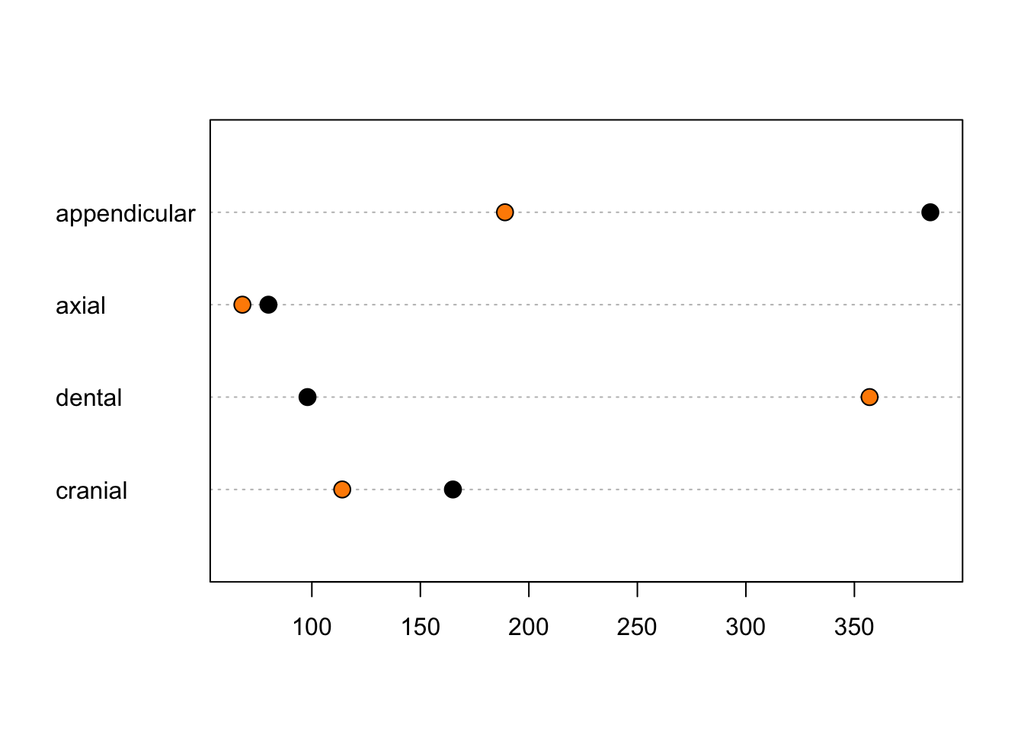

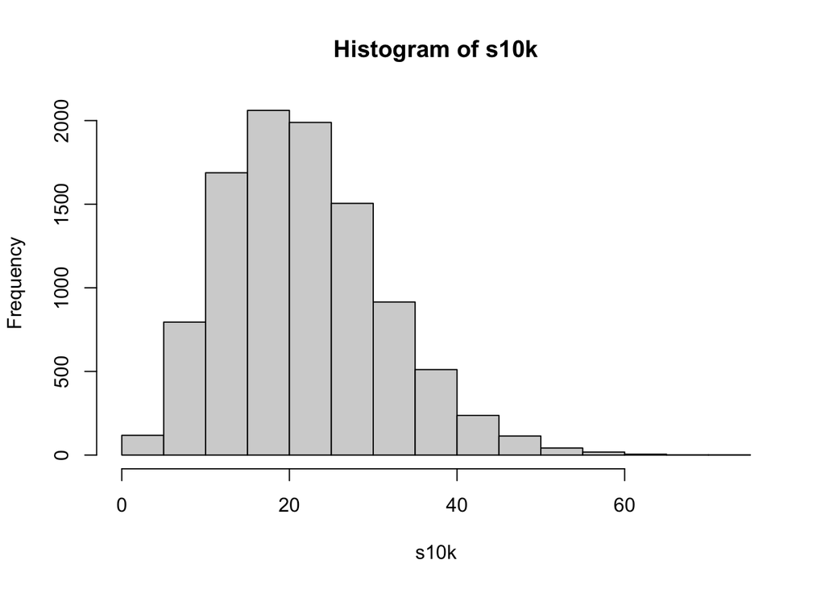

Figure 1. Histogram of distance measurements between simulated and observed counts of skeletal element regions